# Tala data science challenge problem

## by Nastaran Bassamzadeh

1. Introduction
2. Data cleaning
3. Feature engineering
4. Exploratory analysis
5. Classification model
6. Conclusion

### Introduction

[ go back to the top ]

As part of the Tala data science challenge problem, I was given two csv data files. The first file, "dataScienceChallenge_callLog.csv" contains a sample of call log of people who are using Tala service. The second dataset "dataScienceChallenge_repayment.csv" records the repayment status of the customers who have got a loan from Tala. The goal is to build a model to predict the repayment status according to the data that can be extracted from call logs.

```python
import os
import re
from time import time
import pandas as pd
import numpy as np
from scipy import interp
import seaborn as sb
import matplotlib.pyplot as plt
from sklearn.model_selection import cross_val_score, RandomizedSearchCV, StratifiedKFold
from sklearn.ensemble import RandomForestClassifier, GradientBoostingClassifier
from sklearn.preprocessing import Imputer, LabelEncoder
from sklearn.metrics import roc_curve, auc

get_ipython().run_line_magic('matplotlib', 'inline')
sb.set(color_codes=True)
```

### Data cleaning

[ go back to the top ]

First, we would like to see a general description of the data and specifically the number of missing values. The function "checking_na" examines a dataframe and returns the count and percentage of missing values in each column.

#### Loan_repayment dataset

```python
def checking_na(df):
    """ This function finds the count and percentage of missing values in the columns of a dataframe """
    df_na_bool = pd.concat([df.isnull().any(), df.isnull().sum(), (df.isnull().sum() / df.shape[0]) * 100],
                           axis=1, keys=['df_bool', 'df_amt', 'missing_ratio_percent'])
    df_na_bool = df_na_bool.loc[df_na_bool['df_bool'] == True]
    return df_na_bool
```

```python
loandf = pd.read_csv("./dataScienceChallenge_repayment.csv")
print(checking_na(loandf))
```

```
Empty DataFrame
Columns: [df_bool, df_amt, missing_ratio_percent]
Index: []
```

```python
print(loandf.describe(include='all'))
loandf.set_index('person_id_random', inplace=True)
```

```
        person_id_random signup_date disbursement_date  paid_first_loan
count       1.250000e+03        1250              1250      1250.000000
unique               NaN         379               700              NaN
top                  NaN  2016-02-24        2015-08-21              NaN
freq                 NaN          18                10              NaN
mean        5.527011e+09         NaN               NaN         0.820000
std         2.585785e+09         NaN               NaN         0.384341
min         1.008312e+09         NaN               NaN         0.000000
25%         3.227986e+09         NaN               NaN         1.000000
50%         5.534345e+09         NaN               NaN         1.000000
75%         7.694413e+09         NaN               NaN         1.000000
max         9.998624e+09         NaN               NaN         1.000000
```

From the above results, we can see that loan_repayment dataset has no missing values and has 1250 rows. Also, we set the "person_id_random" as the index. We also invetigate the distribution of the "paid_first_loan" column as the class variable:

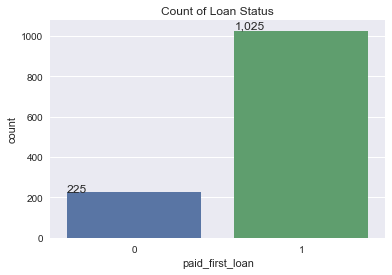

```python
ax = sb.countplot(loandf.paid_first_loan)
ax.set_title("Count of Loan Status")
for p in ax.patches:
    ax.annotate(str(format(int(p.get_height()), ',d')), (p.get_x(), p.get_height() * 1.01))
```

We see that 1025 people have repaid their loans while 225 have not. The only feature that we build from this dataset is the time lag between sign up date and the loan disbursmenta and thus add the "days_from_signup_to_disbursement" column to the dataset.

```python
loandf.signup_date = pd.to_datetime(loandf.signup_date)
loandf.disbursement_date = pd.to_datetime(loandf.disbursement_date)
loandf['days_from_signup_to_disbursement'] = (loandf['disbursement_date'] - loandf['signup_date']).dropna().dt.days
```

#### Call log dataset

First, let's look at the description of the data and the satus of missing values.

```python
calldf = pd.read_csv("./dataScienceChallenge_callLog.csv")
print(calldf.describe(include='all'))
print(checking_na(calldf))
```

```
        person_id_random phone_randomized contact_name_redacted direction  \
count       1.349058e+06          1349058               1072382   1349058
unique               NaN           224362                 13589         4
top                  NaN        000709915                 Xxxxx  outgoing
freq                 NaN            10195                107697    776903
mean        5.529126e+09              NaN                   NaN       NaN
std         2.563607e+09              NaN                   NaN       NaN
min         1.008312e+09              NaN                   NaN       NaN
25%         3.315068e+09              NaN                   NaN       NaN
50%         5.456093e+09              NaN                   NaN       NaN
75%         7.545986e+09              NaN                   NaN       NaN
max         9.998624e+09              NaN                   NaN       NaN

            duration      local_timestamp
count   1.349058e+06              1349058
unique           NaN              1327760
top              NaN  2016-03-13 03:00:00
freq             NaN                    6
mean    4.322104e+01                  NaN
std     1.692588e+02                  NaN
min    -1.000000e+00                  NaN
25%     0.000000e+00                  NaN
50%     1.200000e+01                  NaN
75%     4.400000e+01                  NaN
max     1.281280e+05                  NaN
                       df_bool  df_amt  missing_ratio_percent
contact_name_redacted     True  276676              20.508829
```

We see that "contact_name_redacted" is the only column with missing values (20.5 percent). Also, we see that the top occuring "phone_randomized" value is "000709915" which seems to be wrong since it starts with 0. The 'direction' column has 4 unique categories. The "duration" variable min and max are not rational and needs to be further analyzed. let's see the summary of what we have,

```python
print("The data contains {} observations with {} columns".format(calldf.shape[0], calldf.shape[1]))
print("The data contains {} unique person IDs".format(calldf.person_id_random.nunique()))
print("There are {} unique categories in the call directions".format(calldf.direction.nunique()))
print("The duration of calls range from {} to {}".format(calldf.duration.min(), calldf.duration.max()))
print("The data are collected from {} to {}".format(calldf.local_timestamp.min(), calldf.local_timestamp.max()))
```

```
The data contains 1349058 observations with 6 columns
The data contains 1216 unique person IDs
There are 4 unique categories in the call directions
The duration of calls range from -1 to 128128
The data are collected from 1970-01-02 03:01:40 to 2037-12-31 16:50:24
```

We will examine and clean each column separately. Before that we assign appropriate datatypes to each column.

```python
calldf.phone_randomized = calldf.phone_randomized.astype(str)
calldf.contact_name_redacted = calldf.contact_name_redacted.astype(str)
calldf.direction = calldf.direction.astype('category')
calldf.local_timestamp = pd.to_datetime(calldf.local_timestamp)
```

```python
calldf.dtypes
```

```
person_id_random                  int64
phone_randomized                 object
contact_name_redacted            object
direction                      category
duration                          int64
local_timestamp          datetime64[ns]
dtype: object
```

#### Cleaning call log data

First, we make sure the phone numbers are legit. using regular expressions we only keep the ones that have 9 digits and do not start with zero. We replace the wrong entries with NaN (missing values)

```python
r = re.compile('\d{9}')

def iscontactlegible(x):
    if r.match(x) and len(x) == 9 and str(x[0]) != '0':
        return x
    else:
        return np.nan


calldf.phone_randomized = calldf.phone_randomized.apply(iscontactlegible)
```

Next, we replace the missing values in "contact_name_redacted" with the string 'not_in_contacts'. The reason is that these missing values show that person has talked to somebody whose phone number is not saved in his contact list. So, it represents an important feature and shoud be included appropriately.

```python
calldf.contact_name_redacted = calldf.contact_name_redacted.apply(lambda x: 'not_in_contacts' if x == 'nan' else x)
```

Now, let's see the duration column,

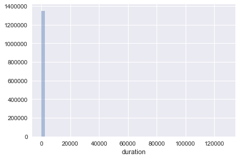

```python
sb.distplot(calldf.duration, kde=False)
```

It definitely has some outliers. We replace negative duration values with 0 and also the values over 95 percentile with the mean of non outlier values. So, the distribution of duration column would be as follows,

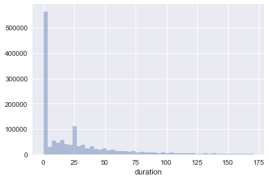

```python
calldf.loc[calldf.duration < 0, 'duration'] = 0
non_outlier_mean = calldf.duration[calldf.duration < np.percentile(calldf.duration, 95)].mean()
calldf.loc[calldf.duration > np.percentile(calldf.duration, 95), 'duration'] = non_outlier_mean
sb.distplot(calldf.duration, kde=False)
```

Moreover, if the call duration is zero and it is labeled as "incoming', we replace the label by "missed".

```python
calldf.loc[((calldf.duration == 0) & (calldf.direction == 'incoming')), 'direction'] = 'missed'
```

Now, we look at the distrubtion of year, month, weekday and hour of the "local_timestamp" column.

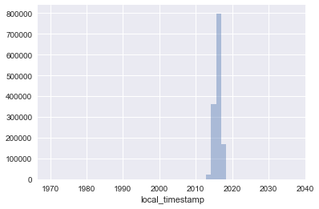

```python
sb.distplot(calldf.local_timestamp.dt.year, kde=False)
```

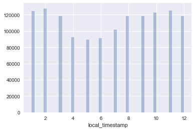

```python
sb.distplot(calldf.local_timestamp.dt.month, kde=False)
```

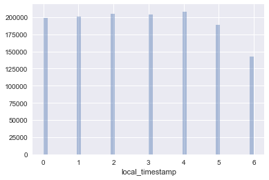

```python
sb.distplot(calldf.local_timestamp.dt.weekday, kde=False)
```

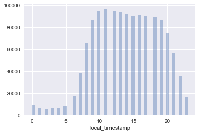

```python
sb.distplot(calldf.local_timestamp.dt.hour, kde=False)
```

They all seem reasonable except the year which we already saw was ranging from 1970 to 2037. We remove all datetime entries whose year is less than 2012 or greater than 2018. Now, the year distrubtion will be as follow. Finally, we check the missing values and see that a negligible percentage of two columns is missing.

```
                  df_bool  df_amt  missing_ratio_percent
phone_randomized     True   11574               0.857932
local_timestamp      True     118               0.008747
```

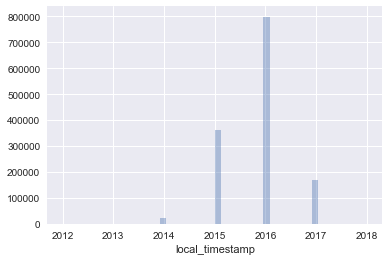

```python
calldf.loc[~calldf.local_timestamp.dt.year.isin(range(2012, 2019)), 'local_timestamp'] = np.nan
sb.distplot(calldf.local_timestamp.dt.year[~np.isnan(calldf.local_timestamp.dt.year)], kde=False)
print(checking_na(calldf))
```

### Feature engineering

[ go back to the top ]

We look to build features that represent the charactristics of the customers from the mobile phone data. Based on the literature, these attributes realated to call log data fall under 4 braod categories:

```
1. Basic phone use (e.g. number of calls, number of unique contacts, number of unique area codes, mean and standard
deviation of call duration )
2. Active user behavior (e.g. percent of incoming/outgoing calls, percent during night/business hours ratio)
3. Regularity (e.g. inter-event time between calls)
4. Diversity (e.g. call entropy, contacts to interaction ratio)
```

The features that we extract will be calculated for each unique person ID. We extract features as follows,

##### Features from 'phone_randomized':

a. Count of unique phone numbers that a particular person has talked to.

```python
call_by_person = calldf.groupby(['person_id_random']).phone_randomized.nunique().to_frame('unique_contacts_count')
```

b. Count of unique area codes that a particular person has talked to.

```python
calldf['area_code'] = calldf.phone_randomized.apply(lambda x: str(x)[:3])
call_by_person['unique_areacode_count'] = calldf.groupby(['person_id_random']).area_code.nunique()
```

c. Calculating entropy of calls:

The entropy is a measure of the spread of the interactions. Users with low entropy tend to mainly conact a few individuals while largley ignoring the rest. On the other had, people with high entropy contact people more equally. The entropy is defined as: $$ S_u=\sum_c(n_c/n_t)log_2(n_c/n_t) $$
where index $c$ represnts each unique phone number that the user has contacted, $n_c$ denoted the number of interactions with contact $c$ and $n_t=\sum_cn_c$ is the total number of interactions.

```python
contact_by_person = calldf[calldf['direction'] != 'missed'].groupby(
    ['person_id_random', 'phone_randomized']).size().to_frame('unique_phone_count').reset_index()
sum_contact_by_person = calldf[calldf['direction'] != 'missed'].groupby(['person_id_random']).size().to_frame(
    'total_count').reset_index()
merged_counts_df = pd.merge(contact_by_person, sum_contact_by_person, on='person_id_random', how='left')
merged_counts_df['entropy'] = -(merged_counts_df['unique_phone_count'] / merged_counts_df['total_count']) * np.log2(
    merged_counts_df['unique_phone_count'] / merged_counts_df['total_count'])
call_by_person['entropy'] = (merged_counts_df.groupby(['person_id_random']).entropy.sum()).round(2)
```

##### Features from 'contact_name_redacted':

Here, we define categories for the "contact_name_redacted" column based on the format the user has saved the conatct name. First category is "not_in_contacts" for the cases where conatct name has not been saved. Second category is for those names that have been only saved by one word, and the lst catgory covers all other cases.

```python
def typeofcontact(x):
    if x == 'not_in_contacts':
        return 'not_in_contacts'
    elif not (re.split('\S+', x)[1]):
        return 'one_word'
    else:
        return 'other_types'


calldf['type_of_contact'] = calldf.contact_name_redacted.apply(typeofcontact)
types_counts = calldf.groupby(['person_id_random', 'type_of_contact']).size().unstack()
types_counts['types_sum'] = (types_counts['not_in_contacts'].fillna(0) + types_counts['one_word'].fillna(0) +
                             types_counts['other_types'].fillna(0))
call_by_person['percent_one_word'] = ((types_counts['one_word'] / types_counts['types_sum']) * 100).round(2)
call_by_person['percent_not_in_contacts'] = ((types_counts['not_in_contacts'] / types_counts['types_sum']) * 100).round(
    2)
```

##### Features from 'direction':

Here, we define four features namely, the total number of calls, the percent of incoming calls, the percent of outgoing calls and the percent of missed calls. It should be noted that since we have 4 categories for direction of phone calls these percents do not add up to one.

```python
direction_counts = calldf.groupby(['person_id_random', 'direction']).size().unstack()
call_by_person['call_count'] = (direction_counts['incoming'].fillna(0) + direction_counts['outgoing'].fillna(0) +
                                direction_counts['missed'].fillna(0) + direction_counts['unknown'].fillna(0))
call_by_person['percent_incoming'] = ((direction_counts['incoming'] / call_by_person['call_count']) * 100).round(2)
call_by_person['percent_outgoing'] = ((direction_counts['outgoing'] / call_by_person['call_count']) * 100).round(2)
call_by_person['percent_missed'] = ((direction_counts['missed'] / call_by_person['call_count']) * 100).round(2)
```

Also, we define 'contacts_to_interactions_ratio' which represents the spread of the phone calls and is a measure of diversity.

```python
call_by_person['contacts_to_interactions_ratio'] = (
    call_by_person['unique_contacts_count'] / call_by_person['call_count']).round(2)
```

##### Features from 'duration':

Here, we calculate the mean and standard deviation of the phone call duration for each individual.

```python
call_by_person['call_duration_mean_minute'] = (
    calldf[calldf['duration'] != 0].groupby(['person_id_random']).duration.mean()).dropna().astype(int)
call_by_person['call_duration_std_minute'] = (
    calldf[calldf['duration'] != 0].groupby(['person_id_random']).duration.std()).dropna().astype(int)
```

###### Features from 'local_timestamp'

First, we calculate percentage of calls that happen at night time from 10 pm to 7 am.

```python
total_duration = calldf.groupby(['person_id_random']).duration.sum()
# calculating percentage of call durations at nights
nightcall_duration = calldf[calldf['local_timestamp'].dt.hour.isin([0, 1, 2, 3, 4, 5, 6, 22, 23])].groupby(
    ['person_id_random']).duration.sum()
call_by_person['percent_nightcalls_duration'] = ((nightcall_duration / total_duration) * 100).round(2)
```

Second, we calculate percentage of calls that happen during business hours in weekdays.

```python
businesshours_call_duration = calldf[
    calldf['local_timestamp'].dt.hour.isin([9, 10, 11, 12, 13, 14, 15, 16]) & calldf['local_timestamp'].dt.weekday.isin(
        [0, 1, 2, 3, 4])].groupby(['person_id_random']).duration.sum()
call_by_person['percent_businesshours_calls_duration'] = ((businesshours_call_duration / total_duration) * 100).round(2)
```

Finally, we caluclate the mean and standard deviation of the time lag between the call events for each indivdual. This represents how often he talks on the phone.

```python
for personID, group in calldf.groupby(['person_id_random']):
    normal_times = group.loc[~(group.local_timestamp.isnull()), 'local_timestamp'].sort_values()
    shifted_times = normal_times.shift(1)  # Shift the timestamps down to calculate the time differences
    delta = (normal_times - shifted_times).iloc[1:]
    minutes_lag = delta.apply(lambda x: x.total_seconds() / 60)
    if not (pd.isnull(minutes_lag.mean()) or pd.isnull(minutes_lag.std())):
        call_by_person.loc[personID, 'inter_event_duration_mean_minute'] = int(minutes_lag.mean())
        call_by_person.loc[personID, 'inter_event_duration_std_minute'] = int(minutes_lag.std())
    else:
        call_by_person.loc[personID, 'inter_event_duration_mean_minute'] = 0
        call_by_person.loc[personID, 'inter_event_duration_std_minute'] = 0
```

Finally, we have built all the features that we thought are informative. We left merge the dataframe consisting of new features from call log data to the dataframe of loan repayment data that we initially had. Thus we have the features built for each individual in one single dataframe called "call_loan_df". We check the missing values in this new file and see that they are not many.

```python
call_loan_df = pd.merge(call_by_person, loandf[['days_from_signup_to_disbursement', 'paid_first_loan']],
                        left_index=True, right_index=True, how='left')
print(checking_na(call_loan_df))
call_loan_df.to_csv("./call_loan.csv")
```

```
                                      df_bool  df_amt  missing_ratio_percent
percent_one_word                         True      14               1.151316
percent_not_in_contacts                  True       9               0.740132
percent_incoming                         True       5               0.411184
percent_outgoing                         True       4               0.328947
percent_missed                           True      16               1.315789
call_duration_std_minute                 True       8               0.657895
percent_nightcalls_duration              True      32               2.631579
percent_businesshours_calls_duration     True       9               0.740132
```

```python
call_loan_df.head()
```

| person_id_random | unique_contacts_count | unique_areacode_count | entropy | percent_one_word | percent_not_in_contacts | call_count | percent_incoming | percent_outgoing | percent_missed | contacts_to_interactions_ratio | call_duration_mean_minute | call_duration_std_minute | percent_nightcalls_duration | percent_businesshours_calls_duration | inter_event_duration_mean_minute | inter_event_duration_std_minute | days_from_signup_to_disbursement | paid_first_loan |
| --- | --- | --- | --- | --- | --- | --- | --- | --- | --- | --- | --- | --- | --- | --- | --- | --- | --- | --- |
| 1008312365 | 662 | 67 | 7.69 | 26.39 | 10.57 | 5419.0 | 33.25 | 46.43 | 15.76 | 0.12 | 41 | 35.0 | 4.73 | 51.57 | 111.0 | 1523.0 | 183 | 1 |
| 1050745693 | 194 | 53 | 5.57 | 53.38 | 9.07 | 1433.0 | 39.01 | 49.13 | 11.03 | 0.14 | 41 | 35.0 | 11.24 | 35.31 | 472.0 | 13057.0 | 360 | 1 |
| 1052058623 | 165 | 53 | 5.89 | 37.52 | 11.71 | 1042.0 | 32.73 | 52.78 | 14.49 | 0.16 | 44 | 38.0 | 6.13 | 54.83 | 786.0 | 10023.0 | 3 | 1 |
| 1058241029 | 213 | 52 | 6.19 | 52.60 | 20.54 | 2439.0 | 26.94 | 63.84 | 9.23 | 0.09 | 32 | 30.0 | 5.96 | 40.04 | 240.0 | 1169.0 | 63 | 1 |
| 1060418185 | 214 | 58 | 5.55 | 51.03 | 14.08 | 1648.0 | 34.83 | 55.76 | 9.34 | 0.13 | 40 | 35.0 | 4.06 | 47.65 | 630.0 | 10206.0 | 8 | 1 |

### Exploratory analysis

[ go back to the top ]

```python
loan_data = pd.read_csv("./call_loan.csv")
loan_data.drop(['person_id_random'], axis=1, inplace=True)
loan_data = loan_data.dropna()
```

First, we plot the distribution of each attribute. We see that some of the attributes have a highly skewed distribution. Since we are planning to use ensemble of trees as the calssifier model we don't need to apply log tranform to these variables. However, if we later decide to use other types of classifiers we need to make sure that these variables are normalized. Also, for the same reason we do not need to transform variables to have similar scales.

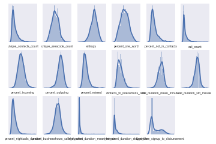

```python
for column_index, column in enumerate(loan_data.columns):
    if column == 'paid_first_loan':
        continue
    plt.subplot(3, 6, column_index + 1)
    b=sb.distplot(loan_data[column])
    b.set_xlabel(xlabel=column,fontsize=5)
    b.set(yticks=[])
    b.set(xticks=[])
```

In order to use random forest classifier, we need to examine the monotonicity relation between features and the class variable. Thus, we plot the probability of loan repayment versus each attribute. If the relation is not monotonic, we need to discretize the attribute to be used in the random forest algorithm.

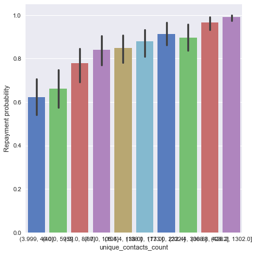

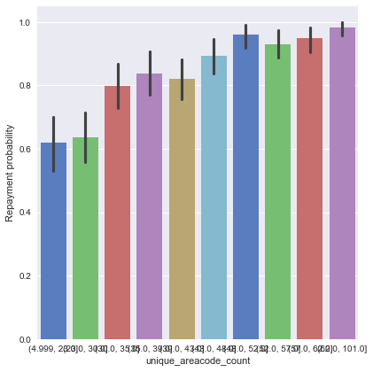

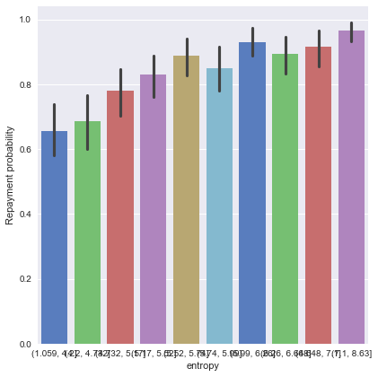

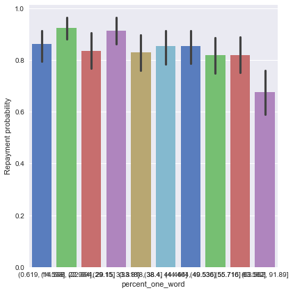

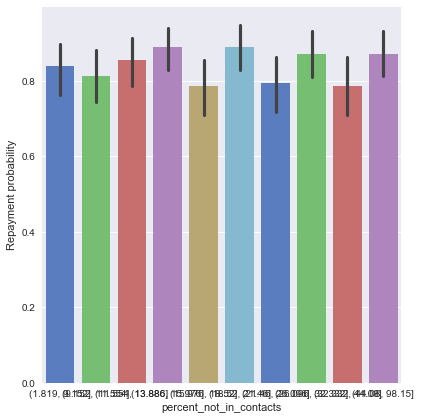

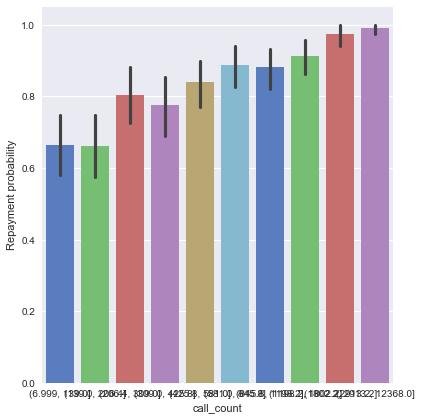

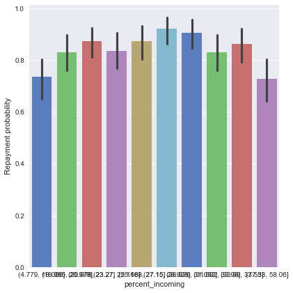

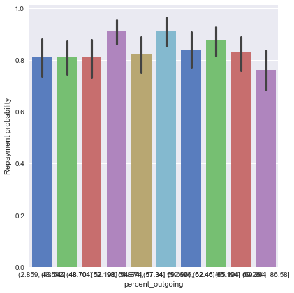

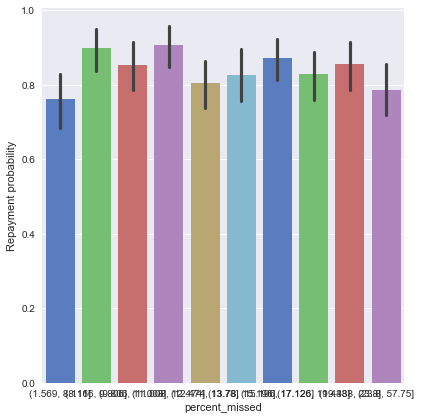

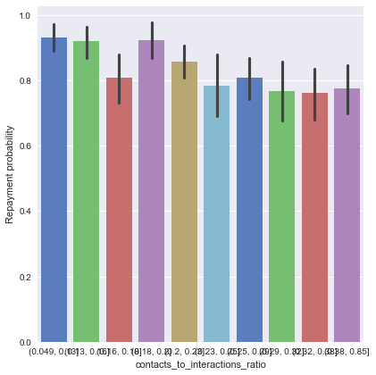

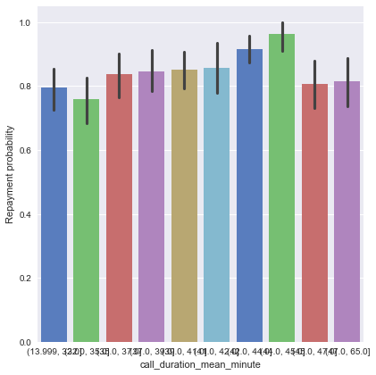

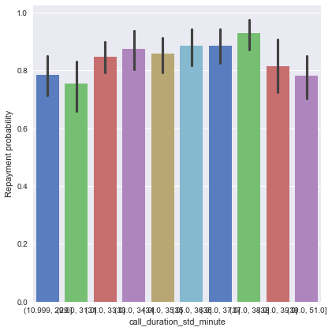

[5 more figures not shown]

```python
data = loan_data.copy()
for column_index, column in enumerate(data.columns):
    if column == 'paid_first_loan':
        continue
    data[column] = pd.qcut(data[column], 10, duplicates='drop')
    g = sb.factorplot(x=column, y="paid_first_loan", data=data, size=6, kind="bar", palette="muted")
    g.set_ylabels("Repayment probability")
```

By examining the above figures we realize that the following attributes do not hold a monotone relation with the class variable: